# Example3

```r
dwtest(Chla~pH+BOD+COD+TN+TP+EC+PO4P+Rain,data=ex2_scale) # 잔차가 양의 자기상관성을 가지고 있음.
```

```
##
##  Durbin-Watson test
##
## data:  Chla ~ pH + BOD + COD + TN + TP + EC + PO4P + Rain
## DW = 1.4481, p-value = 6.712e-11
## alternative hypothesis: true autocorrelation is greater than 0
```

```r
gfit2 <- lm(Chla~pH+BOD+COD+TN+TP+EC+PO4P,data=ex2_scale) # 모형 gfit1에서 유의하지 않은 변수를 제외함.
summary(gfit2) # Adjusted R-squared:  0.6918
```

```
##
## Call:
## lm(formula = Chla ~ pH + BOD + COD + TN + TP + EC + PO4P, data = ex2_scale)
##
## Residuals:
##      Min       1Q   Median       3Q      Max
## -1.97784 -0.29583 -0.04292  0.24084  2.46374
##
## Coefficients:
##               Estimate Std. Error t value Pr(>|t|)
## (Intercept)  1.525e-17  2.456e-02   0.000 1.000000
## pH           1.960e-01  2.913e-02   6.728 4.70e-11 ***
## BOD          3.669e-01  4.371e-02   8.393 4.83e-16 ***
## COD          1.078e-01  4.443e-02   2.427 0.015585 *
## TN          -1.417e-01  2.875e-02  -4.928 1.13e-06 ***
## TP           1.527e-01  3.952e-02   3.863 0.000127 ***
## EC           1.263e-01  2.953e-02   4.277 2.27e-05 ***
## PO4P        -3.736e-01  3.710e-02 -10.071  < 2e-16 ***
## ---
## Signif. codes:  0 '***' 0.001 '**' 0.01 '*' 0.05 '.' 0.1 ' ' 1
##
## Residual standard error: 0.5552 on 503 degrees of freedom
## Multiple R-squared:  0.696,  Adjusted R-squared:  0.6918
## F-statistic: 164.5 on 7 and 503 DF,  p-value: < 2.2e-16
```

```r
vif(gfit2)
```

```
##       pH      BOD      COD       TN       TP       EC     PO4P
## 1.403728 3.161689 3.266886 1.367715 2.584347 1.443108 2.277481
```

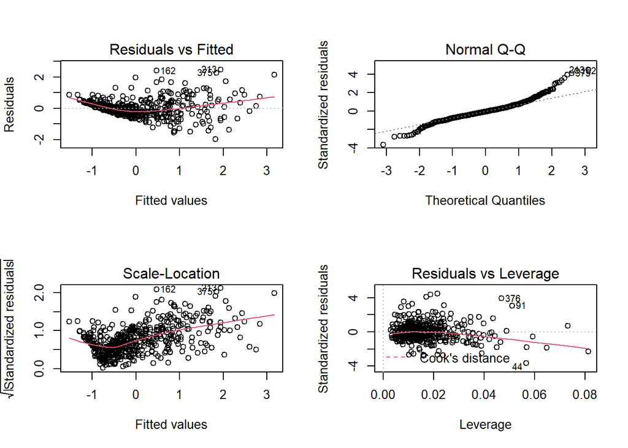

```r
par(mfrow=c(2,2))
plot(gfit2)
```

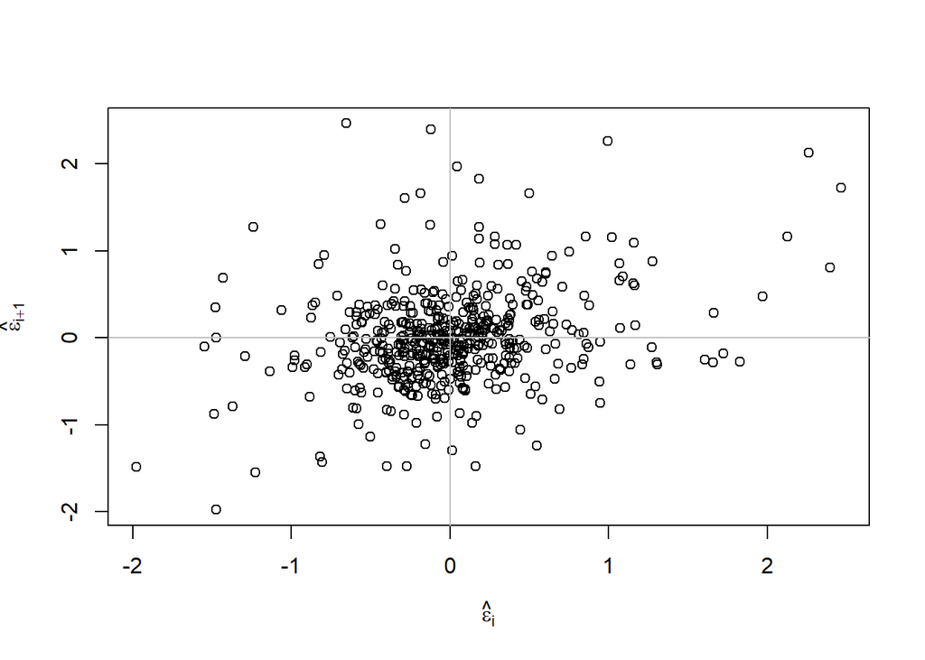

```r
par(mfrow=c(1,1))
n <- length(residuals(gfit2))
plot(tail(residuals(gfit2),n-1) ~ head(residuals(gfit2),n-1), xlab= expression(hat(epsilon)[i]),ylab=expression(hat(epsilon)[i+1]))
abline(h=0,v=0,col=grey(0.75))
```

```r
dwtest(Chla~pH+BOD+COD+TN+TP+EC+PO4P,data=ex2_scale)
```

```
##
##  Durbin-Watson test
##
## data:  Chla ~ pH + BOD + COD + TN + TP + EC + PO4P
## DW = 1.4414, p-value = 4.268e-11
## alternative hypothesis: true autocorrelation is greater than 0
```

```r
# 다중회귀분석에 대한 기본가정인 잔차(residual)에 대한 정규성, 등분산성, 독립성, 선형성 등을 만족하지 못함.
```

### Generalized Additive Model

#### scaling data 사용

```r
mm <- gam(Chla~s(pH)+s(DO)+s(BOD)+s(COD)+s(SS)+s(TN)+s(TP)+s(TOC)+s(WT)+s(EC)+s(TC)+s(NH3N)+s(PO4P)+s(FC)+s(Flow)+s(Rain),data=ex2_scale)
ggGam(mm)
```

```
##  chr "ggGam(model = mm)"
## List of 1
##  $ model: chr "mm"
```

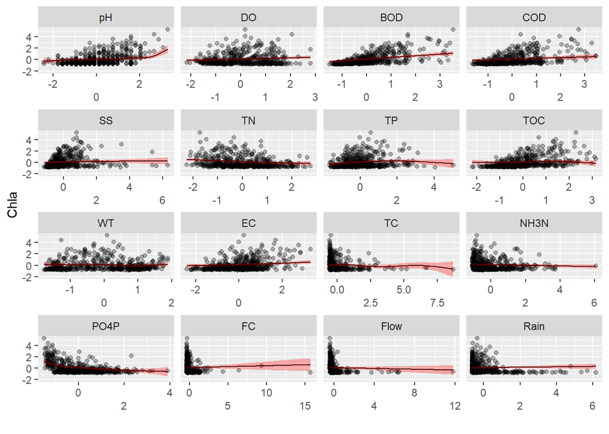

```r
summary(mm) # R-sq.(adj) =  0.753
```

```
##
## Family: gaussian
## Link function: identity
##
## Formula:
## Chla ~ s(pH) + s(DO) + s(BOD) + s(COD) + s(SS) + s(TN) + s(TP) +
##     s(TOC) + s(WT) + s(EC) + s(TC) + s(NH3N) + s(PO4P) + s(FC) +
##     s(Flow) + s(Rain)
##
## Parametric coefficients:
##               Estimate Std. Error t value Pr(>|t|)
## (Intercept) -6.196e-12  2.199e-02       0        1
##
## Approximate significance of smooth terms:
##           edf Ref.df      F  p-value
## s(pH)   7.271  8.176  4.624 1.89e-05 ***
## s(DO)   1.000  1.000  6.072 0.014089 *
## s(BOD)  1.000  1.000 37.858  < 2e-16 ***
## s(COD)  1.000  1.000  4.129 0.042723 *
## s(SS)   1.896  2.389  1.309 0.304284
## s(TN)   1.772  2.240  7.266 0.000546 ***
## s(TP)   2.745  3.509  4.853 0.001553 **
## s(TOC)  3.322  4.193  1.680 0.147131
## s(WT)   3.990  4.959  1.316 0.256857
## s(EC)   1.776  2.266  5.198 0.003687 **
## s(TC)   4.189  5.079  1.503 0.185952
## s(NH3N) 1.000  1.000  2.846 0.092248 .
## s(PO4P) 4.878  5.974 19.261  < 2e-16 ***
## s(FC)   1.000  1.000  0.856 0.355272
## s(Flow) 1.000  1.000  1.078 0.299789
## s(Rain) 1.000  1.000  1.008 0.316010
## ---
## Signif. codes:  0 '***' 0.001 '**' 0.01 '*' 0.05 '.' 0.1 ' ' 1
##
## R-sq.(adj) =  0.753   Deviance explained = 77.2%
## GCV = 0.26801  Scale est. = 0.24711   n = 511
```

```r
concurvity(mm,full=TRUE) # 공선성 존재
```

```
##                  para     s(pH)     s(DO)    s(BOD)    s(COD)     s(SS)
## worst    4.735578e-18 0.6242903 0.8294396 0.8520827 0.9133337 0.9778309
## observed 4.735578e-18 0.5484708 0.8079799 0.8356261 0.9040264 0.8219931
## estimate 4.735578e-18 0.5200332 0.7255592 0.7486376 0.8662414 0.6934910
##              s(TN)     s(TP)    s(TOC)     s(WT)     s(EC)     s(TC)   s(NH3N)
## worst    0.8049606 0.9756349 0.8939112 0.9152732 0.8099510 0.9998189 0.6759951
## observed 0.7686803 0.7643217 0.8090204 0.7494894 0.6578028 0.6610279 0.6041303
## estimate 0.6847002 0.7340731 0.8245603 0.8602089 0.6430269 0.6528593 0.5161292
##            s(PO4P)     s(FC)   s(Flow)   s(Rain)
## worst    0.7453627 0.9998189 0.9940240 0.7808710
## observed 0.7158483 0.8247828 0.8775039 0.7285563
## estimate 0.6722941 0.8245715 0.8938572 0.6703256
```

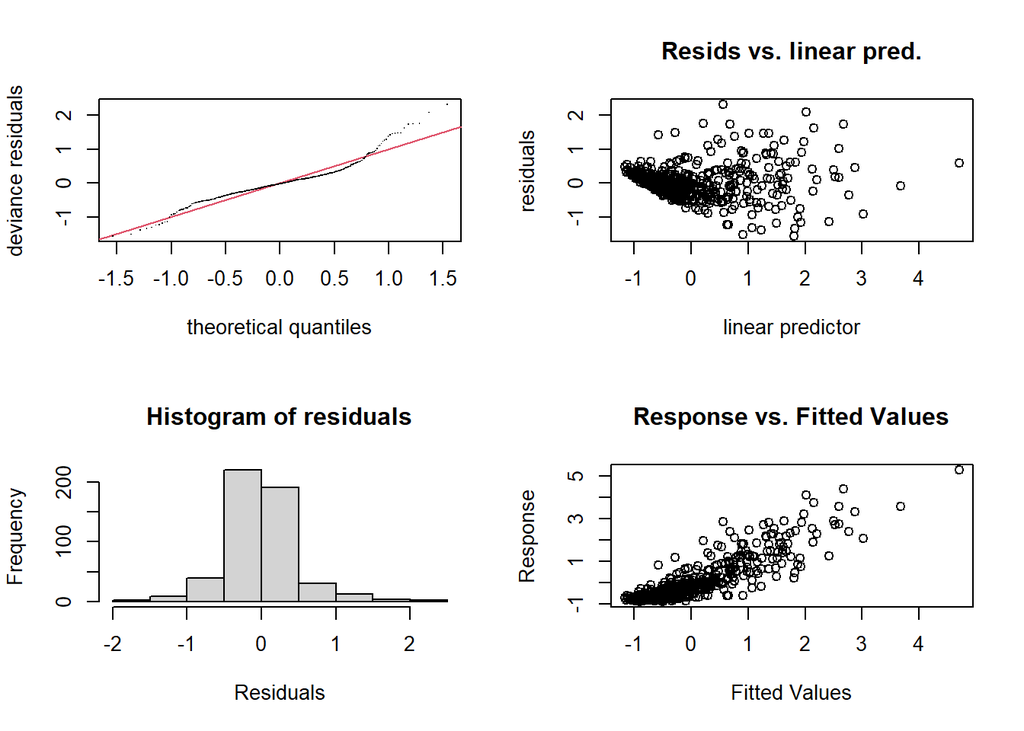

```
##
## Method: GCV   Optimizer: magic
## Smoothing parameter selection converged after 28 iterations.
## The RMS GCV score gradient at convergence was 1.322572e-08 .
## The Hessian was positive definite.
## Model rank =  145 / 145
##
## Basis dimension (k) checking results. Low p-value (k-index<1) may
## indicate that k is too low, especially if edf is close to k'.
##
##           k'  edf k-index p-value
## s(pH)   9.00 7.27    0.97    0.16
## s(DO)   9.00 1.00    0.97    0.26
## s(BOD)  9.00 1.00    1.01    0.53
## s(COD)  9.00 1.00    0.99    0.40
## s(SS)   9.00 1.90    1.03    0.70
## s(TN)   9.00 1.77    0.99    0.39
## s(TP)   9.00 2.75    1.06    0.88
## s(TOC)  9.00 3.32    0.99    0.40
## s(WT)   9.00 3.99    0.91    0.05 *
## s(EC)   9.00 1.78    0.99    0.38
## s(TC)   9.00 4.19    0.99    0.34
## s(NH3N) 9.00 1.00    1.04    0.76
## s(PO4P) 9.00 4.88    1.03    0.69
## s(FC)   9.00 1.00    1.02    0.66
## s(Flow) 9.00 1.00    0.94    0.10
## s(Rain) 9.00 1.00    1.06    0.87
## ---
## Signif. codes:  0 '***' 0.001 '**' 0.01 '*' 0.05 '.' 0.1 ' ' 1
```

```r
par(mfrow=c(2,2))
gam.check(mm)
```

```r
par(mfrow=c(1,1))
mm1 <- gam(Chla~s(pH)+s(DO)+s(BOD)+s(COD)+s(TN)+s(TP)+s(EC)+s(PO4P),data=ex2_scale) # 모형 mm에서 유의하지 않은 변수를 제외하고 모형구축.
ggGam(mm1)
```

```
##  chr "ggGam(model = mm1)"
## List of 1
##  $ model: chr "mm1"
```

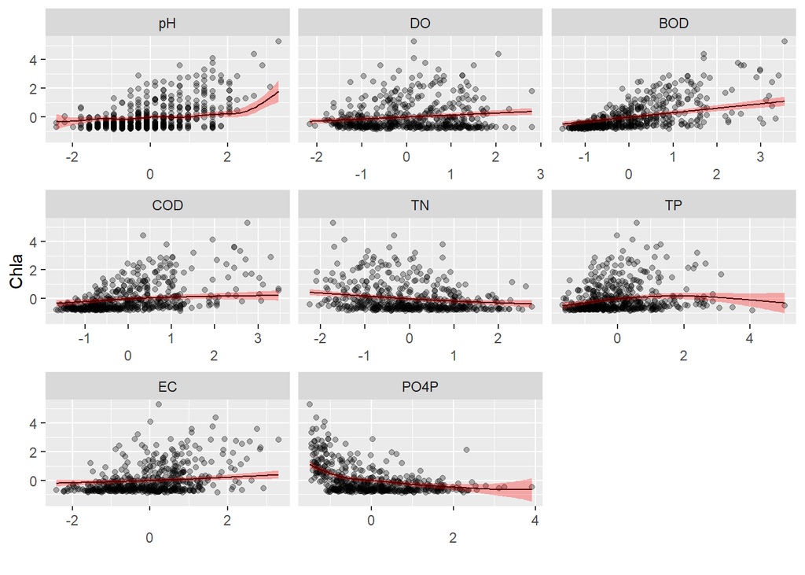

```r
summary(mm1) # R-sq.(adj) =  0.744
```

```
##
## Family: gaussian
## Link function: identity
##
## Formula:
## Chla ~ s(pH) + s(DO) + s(BOD) + s(COD) + s(TN) + s(TP) + s(EC) +
##     s(PO4P)
##
## Parametric coefficients:
##              Estimate Std. Error t value Pr(>|t|)
## (Intercept) 3.837e-12  2.239e-02       0        1
##
## Approximate significance of smooth terms:
##           edf Ref.df      F  p-value
## s(pH)   7.175  8.107  4.957 6.54e-06 ***
## s(DO)   1.000  1.000 16.902 4.64e-05 ***
## s(BOD)  1.000  1.000 56.952  < 2e-16 ***
## s(COD)  1.967  2.485  4.028  0.01438 *
## s(TN)   1.759  2.217 15.915  < 2e-16 ***
## s(TP)   2.804  3.586  7.229 4.45e-05 ***
## s(EC)   1.519  1.885  7.745  0.00224 **
## s(PO4P) 4.928  6.030 22.616  < 2e-16 ***
## ---
## Signif. codes:  0 '***' 0.001 '**' 0.01 '*' 0.05 '.' 0.1 ' ' 1
##
## R-sq.(adj) =  0.744   Deviance explained = 75.5%
## GCV = 0.26831  Scale est. = 0.25616   n = 511
```

```r
concurvity(mm1,full=TRUE) # 공선성 존재
```

```
##                  para     s(pH)     s(DO)    s(BOD)    s(COD)     s(TN)
## worst    3.918092e-18 0.5294636 0.6437623 0.7580388 0.8007126 0.5676038
## observed 3.918092e-18 0.4383608 0.6275457 0.7435924 0.7913274 0.5111455
## estimate 3.918092e-18 0.3791303 0.5295839 0.6347786 0.6391816 0.4265128
##              s(TP)     s(EC)   s(PO4P)
## worst    0.7074804 0.4688887 0.6680059
## observed 0.6415823 0.4253307 0.6229541
## estimate 0.5547252 0.3628748 0.5551020
```

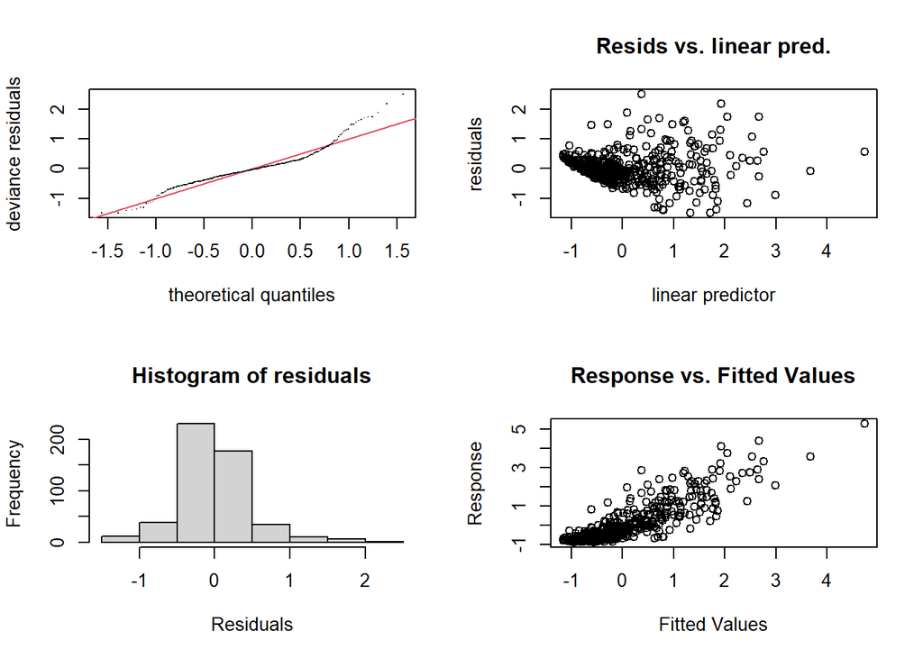

```
##
## Method: GCV   Optimizer: magic
## Smoothing parameter selection converged after 34 iterations.
## The RMS GCV score gradient at convergence was 2.40861e-08 .
## The Hessian was positive definite.
## Model rank =  73 / 73
##
## Basis dimension (k) checking results. Low p-value (k-index<1) may
## indicate that k is too low, especially if edf is close to k'.
##
##           k'  edf k-index p-value
## s(pH)   9.00 7.17    0.99    0.34
## s(DO)   9.00 1.00    0.96    0.20
## s(BOD)  9.00 1.00    1.01    0.46
## s(COD)  9.00 1.97    1.00    0.41
## s(TN)   9.00 1.76    1.01    0.46
## s(TP)   9.00 2.80    1.04    0.79
## s(EC)   9.00 1.52    0.96    0.18
## s(PO4P) 9.00 4.93    1.05    0.91
```

```r
par(mfrow=c(2,2))
gam.check(mm1)
```

```r
par(mfrow=c(1,1))
```

#### 최종선택된 모형의 설명력 : 69.2%(다중선형회귀모형), 74.4%(일반화가법모형) -> 반응변수를 TC로 했을때보다 확실한 차이는 나지 않았음.

#### 일반화가법모형이 다중선형회귀모형보다 설명력이 우수하다는 것을 확실하게 보여주기 위해서는 TC나 FC처럼 설명변수들과 확실한 비선형관계가 있다고 여겨지는 변수를 반응변수로 선택하는 것이 좋다고 판단됨.